# Prediction Assignment Writeup

Xueyi Zhu

7/6/2020

## Background:

Using devices such as Jawbone Up, Nike FuelBand, and Fitbit it is now possible to collect a large amount of data about personal activity relatively inexpensively. These type of devices are part of the quantified self movement – a group of enthusiasts who take measurements about themselves regularly to improve their health, to find patterns in their behavior, or because they are tech geeks. One thing that people regularly do is quantify how much of a particular activity they do, but they rarely quantify how well they do it. In this project, your goal will be to use data from accelerometers on the belt, forearm, arm, and dumbell of 6 participants. They were asked to perform barbell lifts correctly and incorrectly in 5 different ways. More information is available from the website here: http://web.archive.org/web/20161224072740/http:/groupware.les.inf.puc-rio.br/har (see the section on the Weight Lifting Exercise Dataset).

## Data:

The training data for this project are available here:

https://d396qusza40orc.cloudfront.net/predmachlearn/pml-training.csv

The test data are available here:

https://d396qusza40orc.cloudfront.net/predmachlearn/pml-testing.csv

The data for this project come from this source: http://web.archive.org/web/20161224072740/http:/groupware.les.inf.puc-rio.br/har. If you use the document you create for this class for any purpose please cite them as they have been very generous in allowing their data to be used for this kind of assignment.

## Goal:

The goal of your project is to predict the manner in which they did the exercise. This is the “classe” variable in the training set. You may use any of the other variables to predict with. You should create a report describing how you built your model, how you used cross validation, what you think the expected out of sample error is, and why you made the choices you did. You will also use your prediction model to predict 20 different test cases.

## Install and Load Packages:

```r
library(caret)
```

```r
library(ggplot2)
library(rattle)
library(randomForest)
library(rpart)
set.seed(1234)
```

## Data Processing

```r
training <- read.csv("https://d396qusza40orc.cloudfront.net/predmachlearn/pml-training.csv", na.strings = c("NA", " ", "#DIV/0!"))
testing <- read.csv("https://d396qusza40orc.cloudfront.net/predmachlearn/pml-testing.csv", na.strings = c("NA", " ", "#DIV/0!"))

column_sum_na_training <- colSums(is.na(training)) == 0
column_sum_na_testing <- colSums(is.na(testing)) == 0
training <- training[,column_sum_na_training]
testing <- testing[,column_sum_na_testing]

# delete irrelevant variables
training <- training[,-c(1:7)]
testing <- testing[,-c(1:7)]

# split training dataset into two parts: 75% training and 25% validation
inTrain = createDataPartition(training$classe, p = 3/4, list = FALSE)
training_final <- training[inTrain, ]
validation_final <- training[-inTrain, ]
```

## Prediction model 1: Predicting with Trees

```r
training_final$classe = factor(training_final$classe)
modFit <- train(classe ~., method = "rpart", data = training_final)
prediction1 <- predict(modFit, validation_final)
confusionMatrix(table(prediction1, validation_final$classe))
```

```
## Confusion Matrix and Statistics
##
##
## prediction1    A    B    C    D    E
##           A 1274  390  401  386  141
##           B   18  344   36  131  127
##           C  100  215  418  287  244
##           D    0    0    0    0    0
##           E    3    0    0    0  389
##
## Overall Statistics
##
##                Accuracy : 0.4945
##                  95% CI : (0.4804, 0.5086)
##     No Information Rate : 0.2845
##     P-Value [Acc > NIR] : < 2.2e-16
##
##                   Kappa : 0.3385
##
##  Mcnemar's Test P-Value : NA
##
## Statistics by Class:
##
##                      Class: A Class: B Class: C Class: D Class: E
## Sensitivity            0.9133  0.36249  0.48889   0.0000  0.43174
## Specificity            0.6244  0.92111  0.79106   1.0000  0.99925
## Pos Pred Value         0.4915  0.52439  0.33070      NaN  0.99235
## Neg Pred Value         0.9477  0.85758  0.87995   0.8361  0.88652
## Prevalence             0.2845  0.19352  0.17435   0.1639  0.18373
## Detection Rate         0.2598  0.07015  0.08524   0.0000  0.07932
## Detection Prevalence   0.5285  0.13377  0.25775   0.0000  0.07993
## Balanced Accuracy      0.7688  0.64180  0.63997   0.5000  0.71550
```

## Prediction Model 2: Random Forest

```r
training_final$classe = factor(training_final$classe)
modFit2 <- randomForest(classe ~. , data = training_final)
prediction2 <- predict(modFit2, validation_final)
confusionMatrix(table(prediction2, validation_final$classe))
```

```
## Confusion Matrix and Statistics
##
##
## prediction2    A    B    C    D    E
##           A 1395    5    0    0    0
##           B    0  943    8    0    0
##           C    0    1  846    6    0
##           D    0    0    1  798    0
##           E    0    0    0    0  901
##
## Overall Statistics
##
##                Accuracy : 0.9957
##                  95% CI : (0.9935, 0.9973)
##     No Information Rate : 0.2845
##     P-Value [Acc > NIR] : < 2.2e-16
##
##                   Kappa : 0.9946
##
##  Mcnemar's Test P-Value : NA
##
## Statistics by Class:
##
##                      Class: A Class: B Class: C Class: D Class: E
## Sensitivity            1.0000   0.9937   0.9895   0.9925   1.0000
## Specificity            0.9986   0.9980   0.9983   0.9998   1.0000
## Pos Pred Value         0.9964   0.9916   0.9918   0.9987   1.0000
## Neg Pred Value         1.0000   0.9985   0.9978   0.9985   1.0000
## Prevalence             0.2845   0.1935   0.1743   0.1639   0.1837
## Detection Rate         0.2845   0.1923   0.1725   0.1627   0.1837
## Detection Prevalence   0.2855   0.1939   0.1739   0.1629   0.1837
## Balanced Accuracy      0.9993   0.9958   0.9939   0.9961   1.0000
```

## Results:

Based on the accuracies of prediction with trees and random forest, we can see that the accuracy of random forest is much higher than the accuracy of prediction with trees. In this case, I would choose random forest as my prediction model.

## Run the Test Model:

```r
test_results <- predict(modFit2, testing)
test_results
```

```
##  1  2  3  4  5  6  7  8  9 10 11 12 13 14 15 16 17 18 19 20
##  B  A  B  A  A  E  D  B  A  A  B  C  B  A  E  E  A  B  B  B
## Levels: A B C D E
```

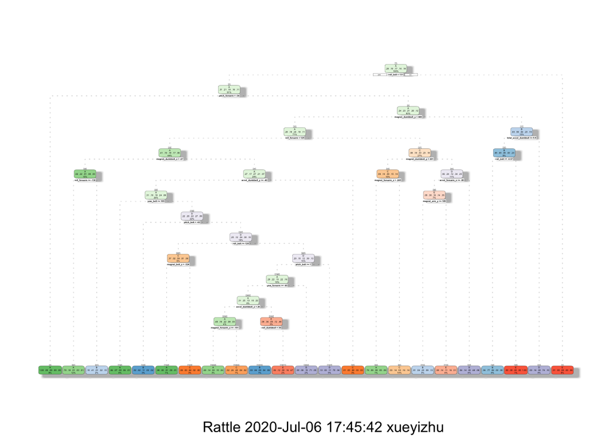

```r
tree <- rpart(classe ~., data = training_final)
fancyRpartPlot(tree)
```